# Distribution of Sample Means

2025

## Setting up the scenario

- Let \(X\) to be the random variable that generates the observed number of spikes per second during the stimulus.
- Assume that the distribution of \(X_{H0}\) is Normal with mean 10 and standard deviation \(\sigma_X = 1\).
- \(X \sim \mathscr{N}(\mu_X=10, \sigma_X=1)\)

## The RV that generates raw data

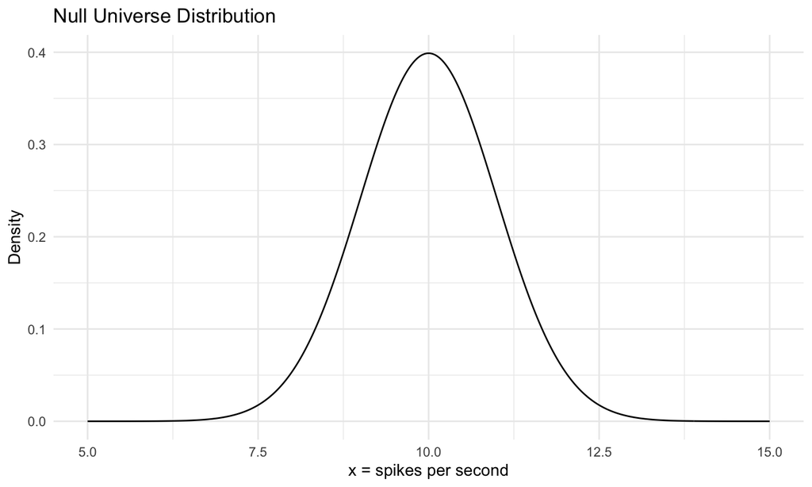

## Raw Data: Experiment 1

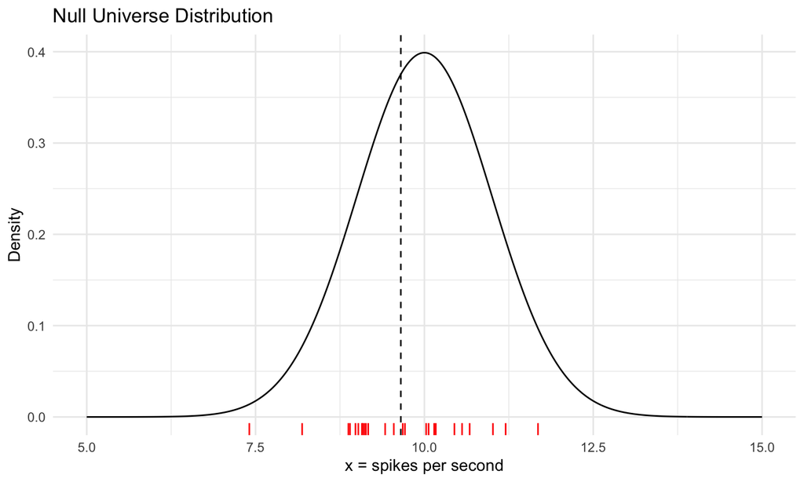

## Raw Data: Experiment 2

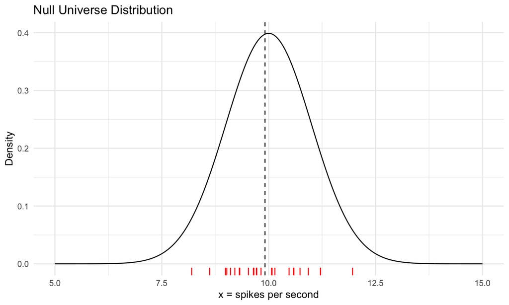

## Raw Data: Experiment 3

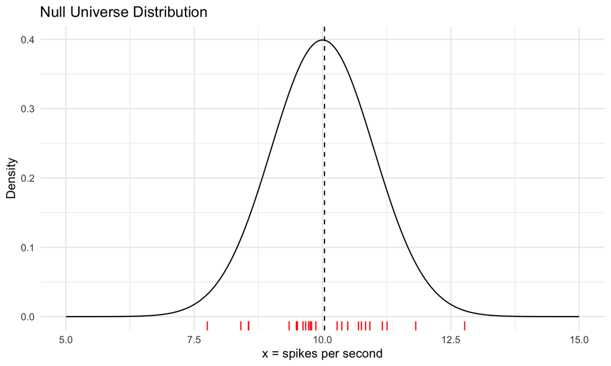

## The sample mean is a random variable

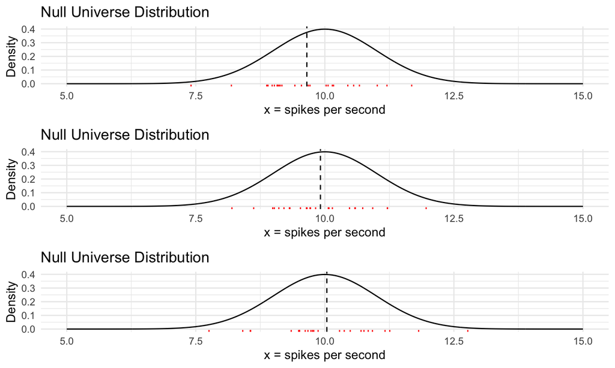

## What is the distribution of \(\bar{X}\)?

- The first way we will answer this question is by performing many experiments until we have observed enough sample means to build compelling histogram.
- 1000 experiments will surely be enough to make a good guess about the disribution of sample means.
- Lets take \(n=25\) observations from \(X\) in each experiment.

## 1000 experiments with \(n=25\)

- \(\bar{X}\) is looks normal with \(\mu_{\bar{X}} = 10\)

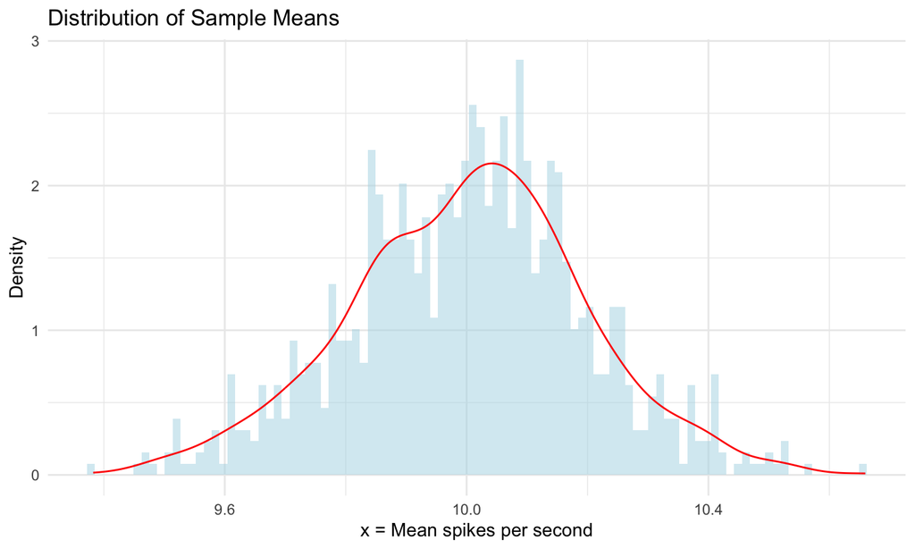

## \(\bar{X}\) compared to \(X\)

- The distribution of \(\bar{X}\) (shown as the histogram) is much narrower than the distribution of \(X\) (shown as the pdf).

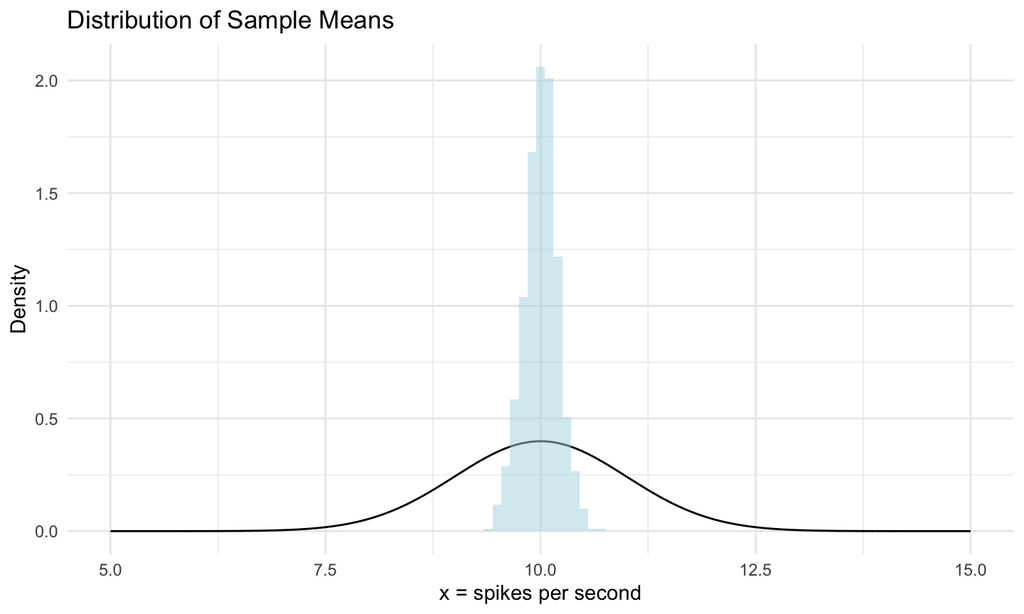

## \(\sigma_{\bar{X}}\) < \(\sigma_X\) and dcreases with \(n\)

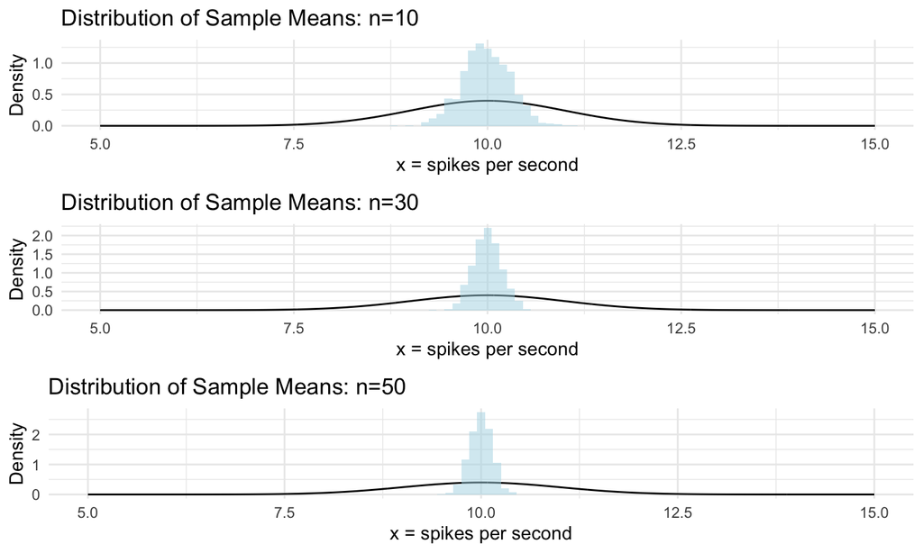

## Concluding…

- It turns out that we can precisely derive the distribution of \(\bar{X}\) from the distribution of \(X\) by using (1) the central limit theorem and (2) the definition of the expected value of a random variable.
- The result of that theorem tell us that:
- The probability distribution of \(\bar{X}\) is Normal with mean \(\mu_{\bar{X}} = \mu_X\) and standard deviation \(\sigma_{\bar{X}} = \frac{\sigma_X}{\sqrt{n}}\).

## The Mean of the Distribution of Sample Means

- When sampling from a population with a mean \(\mu\) and a variance \(\sigma^2\), the mean of the distribution of the sample means is equal to the mean of the population.
- \(\mu_{\bar{X}} = \mu\)
- This property ensures that the sampling distribution of the mean is an unbiased estimator of the population mean.

## The Variance of the Distribution of Sample Means

- The variance of the distribution of sample means decreases as the sample size increases. This is a critical concept, as it underlies the precision increase of our estimates with larger samples.
- \(\sigma^2_{\bar{X}} = \frac{\sigma^2}{n}\)
- This means that the standard deviation of the sampling distribution of the mean, \(\sigma_{\bar{X}}\) (also known as the standard error of the mean), is \(\sigma_{\bar{X}} = \frac{\sigma}{\sqrt{n}}\).
- As \(n\) (sample size) increases, \(\sigma_{\bar{X}}\) decreases, which means the distribution of the sample means becomes narrower, indicating increased precision in estimating the population mean.

## Question

If the population standard deviation is known to be 20, and you have a sample size of 100, what is the standard deviation of the distribution of sample means?

- 20
- 5
- 2
- 0.2

**Answer**

**Correct Answer:** The standard deviation of the distribution of sample means, also known as the standard error, is calculated as the population standard deviation divided by the square root of the sample size \((\sigma_{\bar{x}} = \frac{\sigma}{\sqrt{n}}\). Therefore, with a population standard deviation of 20 and a sample size of 100, the standard error would be \(20 / \sqrt{100} = 20 / 10 = 2\).